# Exploratory data analysis

Adhering to CRISP-DM principles, it is important to obtain a better understanding of the data before preprocessing and modeling.

```python
# Imports

import re
import numpy as np
import pandas as pd
import matplotlib.pyplot as plt
import seaborn as sns
import nltk
nltk.download('punkt')
nltk.download('stopwords')
nltk.download('wordnet')

from nltk import FreqDist

from emotions_model import get_top_words_per_emotion_idx
from emotions_model import generateSentiment
from emotions_model import tokenize
```

# Custom functions

- Other functions pulled from emotions_model.py

```python
def tokenize_and_join(text):
    '''
    INPUT
    text - a string of text

    OUTPUT
    text - a string of text that has been processed with the steps below
        1) Normalize
        2) Remove punctuation
        3) Lemmatize
        4) Stop words removed
    '''
    tokens= tokenize(text)

    tokens=' '.join(tokens)

    return tokens
```

# Data load

```python
df=pd.read_csv('./data/emotion_corpus.txt',sep=';')

print(df.info())
```

```
<class 'pandas.core.frame.DataFrame'>
RangeIndex: 19997 entries, 0 to 19996
Data columns (total 2 columns):
 #   Column    Non-Null Count  Dtype
---  ------    --------------  -----
 0   document  19997 non-null  object
 1   target    19997 non-null  object
dtypes: object(2)
memory usage: 312.6+ KB
None
```

# Section 1:

- 1.1 How many instances of each target category are there?
- 1.2 If we group some of the target categories together into positive/negative/neutral groups, is there a trend?
- 1.3 Using TextBlob, what percent of the data is positive/negative/neutral?
- 1.4 How does the estimated sentiment from #2 compare to the score from 3?

## 1.1 Emotion counts

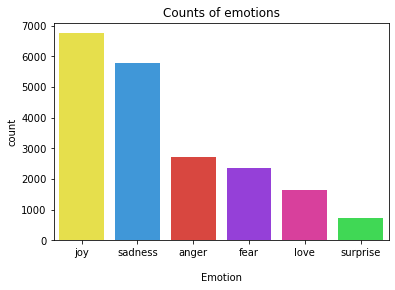

```
Percent of emotions within dataset:

joy         34.0
sadness     29.0
anger       14.0
fear        12.0
love         8.0
surprise     4.0
Name: target, dtype: float64
```

```python
palette_dict={
    'joy':'#FFF633',
    'anger':'#F13027',
    'sadness':'#279BF1',
    'fear':'#9827F1',
    'love':'#F127A1',
    'surprise':'#27F143'
    }


sns.countplot(x=df['target'],order=df['target'].value_counts().index,
              palette=palette_dict)
plt.title('Counts of emotions')
plt.xlabel('\nEmotion')
plt.show()


print('Percent of emotions within dataset:\n')
print(round(df['target'].value_counts(normalize=True),2)*100)
```

- From 1.1:
  - Joy and sadness comprise the majority of the dataset.

## 1.2 Estimate sentiment based on emotion groupings

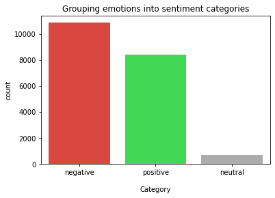

```
Percent of estimated sentiment within dataset:

negative    54.0
positive    42.0
neutral      4.0
Name: est_sentiment, dtype: float64
```

```python
df['est_sentiment']='neutral'
df.loc[df['target'].isin(['joy','love']),'est_sentiment']='positive'
df.loc[df['target'].isin(['anger','fear','sadness']),'est_sentiment']='negative'

est_sent_dict={
    'neutral':'#ACACAC',
    'negative':'#F13027',
    'positive':'#27F143'
    }

sns.countplot(x=df['est_sentiment'],order=df['est_sentiment'].value_counts().index,
              palette=est_sent_dict)
plt.title('Grouping emotions into sentiment categories')
plt.xlabel('\nCategory')
plt.show()


print('Percent of estimated sentiment within dataset:\n')
print(round(df['est_sentiment'].value_counts(normalize=True),2)*100)
```

- From 1.2:
  - Assuming joy/love are positive, anger/fear/sadness are negative, and suprise is neutral the data set is 54% negative, 42% positive,and 4% neutral.

## 1.3 Determine the sentiment based on the TextBlob library

```
          sentiment  sentiment_subjectivity
target
anger     -0.100165                0.478725
fear      -0.059723                0.461128
joy        0.250720                0.552062
love       0.171699                0.572435
sadness   -0.107580                0.490578
surprise   0.044648                0.610824
```

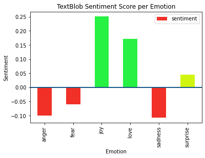

```python
#   Convert the list of numbers to separate columns
df[['sentiment',
    'sentiment_subjectivity']]=pd.DataFrame(df['document'].apply(generateSentiment).tolist(),
                                            index=df.index)

print(pd.pivot_table(df,index='target',
                     values=['sentiment','sentiment_subjectivity']))

sentiment_agg=pd.pivot_table(df,index='target',
                     values=['sentiment','sentiment_subjectivity']).reset_index()


ax=sentiment_agg.plot.bar(x='target',y='sentiment',color=['#F13027','#F13027',
                                                       '#27F143','#27F143',
                                                     '#F13027','#D2F50F'])
ax.axhline(linewidth=2,color='black')
ax.axhline(y=0)
plt.title('TextBlob Sentiment Score per Emotion')
plt.xlabel('Emotion')
plt.ylabel('Sentiment')
plt.show()
```

- From 1.3:
  - the average sentiment for anger, fear, and sadness is less than 0 while the average sentiment for joy and love is greater than 0.
  - the average sentiment for surprise is positive but much closer to 0 since that could be positive or negative
  - The subjectivity for surprise is higher than all the other emotions

## 1.4 Estimated sentiment to TextBlob sentiment

```python
print(pd.pivot_table(df,index='est_sentiment',
                     values=['sentiment','sentiment_subjectivity']))
```

```
               sentiment  sentiment_subjectivity
est_sentiment
negative       -0.095291                0.481200
neutral         0.044648                0.610824
positive        0.235287                0.556041
```

- From 1.4:
  - The negative estimated sentiment matches the TextBlob sentiment since average negative estimated sentiment is less than 0, average neutral sentiment is close to 0, and average positive sentiment is greater than 0

# Section 2a: Word count and common words questions

- 2a.1 How many total and unique words are there?
- 2a.2 What are the most common words?
- 2a.3 What is the term frequency for all words?
- 2a.4 Are there any numbers in any of the records?

## 2a.1 and 2a.2

```python
# Combine all records into one document and make everything lower case
corpus = " ".join(df['document'].values).lower()

# Split by whitespace
word_list = corpus.split()

print(f"Number of words: {len(word_list)}")

print(f"Number of unique words: {len(set(word_list))}")
```

```
Number of words: 382671
Number of unique words: 17096
```

## 2a.3

```python
#2a.3
fd = FreqDist(word_list)

word_counts=pd.DataFrame(fd.most_common(),columns=['word','word_count'])
word_counts['TF']=word_counts['word_count']/word_counts['word_count'].sum()

word_counts.sort_values(by='TF',ascending=False,inplace=True)

word_counts['rank']=word_counts['TF'].rank(method='first',ascending=False)

word_counts['quantile']=pd.qcut(word_counts['rank'],100,labels=np.arange(1,101))

print(word_counts.loc[word_counts['quantile']==1,'word'].head(20))
```

```
0           i
1        feel
2         and
3          to
4         the
5           a
6     feeling
7        that
8          of
9          my
10         in
11         it
12       like
13         so
14         im
15        for
16         me
17        was
18       have
19        but
Name: word, dtype: object
```

## 2a.4

- There are no numbers in any record

```python
df['has_num']=df['document'].str.contains('[0-9]+',regex=True)

print(df['has_num'].value_counts())
```

```
False    19997
Name: has_num, dtype: int64
```

# Section 2b: Word counts and common words questions after stop word removal and lemmatization

- 2b.1 Are there more stop words in one category than another?
- 2b.2 Are there more words in one category than another?
- 2b.3 How many total and unique words are there?
- 2b.4 What are the most common words by term frequency?
- 2b.5 What is the term frequency for all words?

  ## 2b.1 and 2b.2

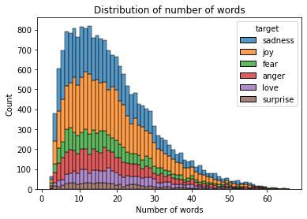

```
          sentiment  sentiment_subjectivity       n_words    n_stop_wds
count  19997.000000            19997.000000  19997.000000  19997.000000
mean       0.048637                0.517306     19.136420      7.398010
std        0.343589                0.312000     10.972127      5.397582
min       -1.000000                0.000000      2.000000     -1.000000
25%       -0.108333                0.300000     11.000000      3.000000
50%        0.000000                0.534286     17.000000      6.000000
75%        0.260000                0.750000     25.000000     10.000000
max        1.000000                1.000000     66.000000     35.000000
          n_stop_wds    n_words
target
anger       7.432632  19.247693
fear        7.183734  18.743363
joy         7.611152  19.426416
love        8.154784  20.611822
sadness     6.976527  18.417328
surprise    7.639777  19.714882
```

```python
df['n_words']=df['document'].str.split('\s').apply(len)
df['document']=df['document'].apply(tokenize_and_join)
df['n_words_stop_rm']=df['document'].str.split('\s').apply(len)
df['n_stop_wds']=df['n_words']-df['n_words_stop_rm']

df.drop(columns=['n_words_stop_rm'],inplace=True)

# N_words distribution based on target
sns.histplot(x=df['n_words'],hue=df['target'],multiple='stack')
plt.title('Distribution of number of words')
plt.xlabel('Number of words')
plt.show()

# Descriptiptive statistics; total and based on target
print(df.describe())

print(pd.pivot_table(df,index='target',values=['n_words','n_stop_wds']))
```

- From 2b.1:
  - The average number of stop words is least in sadness (7) and most in love (8), but the spread is low
- From 2b.2:
  - The average number of words between all categories ranges between 18-20
  - Distribution of words in all categories is similar

## 2b.3-2b.5

```python
# Combine all records into one document and make everything lower case
corpus = " ".join(df['document'].values).lower()


# Split by whitespace
word_list = corpus.split()

print(f"Number of words: {len(word_list)}")

print(f"Number of unique words: {len(set(word_list))}")

fd = FreqDist(word_list)

word_counts=pd.DataFrame(fd.most_common(),columns=['word','word_count'])
word_counts['TF']=word_counts['word_count']/word_counts['word_count'].sum()

word_counts.sort_values(by='TF',ascending=False,inplace=True)

word_counts['rank']=word_counts['TF'].rank(method='first',ascending=False)

word_counts['quantile']=pd.qcut(word_counts['rank'],100,labels=np.arange(1,101))

print(word_counts.loc[word_counts['quantile']==1,'word'].head(20))
```

```
Number of words: 234733
Number of unique words: 15091
0           i
1        feel
2     feeling
3          my
4        like
5          im
6          me
7          wa
8         you
9        time
10     really
11       know
12       very
13     myself
14        get
15       make
16     little
17     people
18        day
19       want
Name: word, dtype: object
```

# Section 3: Top percentile of words for each emotion category

- 3.1 What are the top words in each emotion category by term frequency that are unique to that category?

```python
df,top_words_per_emotion=get_top_words_per_emotion_idx(df,df['target'].unique())

for emotion,words in top_words_per_emotion.items():
    print(f'{emotion} top words:')
    print(words[0:11],'\n\n')
```

```
sadness
Number of words: 66288
Number of unique words: 7124
joy
Number of words: 79883
Number of unique words: 8719
fear
Number of words: 27431
Number of unique words: 4434
anger
Number of words: 32007
Number of unique words: 4962
love
Number of words: 20442
Number of unique words: 3933
surprise
Number of words: 8682
Number of unique words: 2224
sadness top words:
['embarrassed', 'regretful', 'homesick', 'lethargic', 'beaten', 'humiliated', 'unloved', 'abused', 'jaded', 'suffering', 'remorseful']


joy top words:
['fantastic', 'energetic', 'accepted', 'respected', 'glamorous', 'keen', 'ecstatic', 'honored', 'perfect', 'generous', 'intelligent']


fear top words:
['hesitant', 'insecure', 'frantic', 'nervous', 'threatened', 'uncertain', 'vulnerable', 'timid', 'assaulted', 'pressured', 'alarmed']


anger top words:
['annoyed', 'jealous', 'greedy', 'insulted', 'obnoxious', 'impatient', 'furious', 'fucked', 'selfish', 'stubborn', 'bitchy']


love top words:
['kiss', 'sweet', 'accepted', 'tender', 'sympathetic', 'lovely', 'delicate', 'loyal', 'faithful', 'caring', 'devoted']


surprise top words:
['amazed', 'stunned', 'curious', 'dazed', 'shocked', 'impressed']
```

- Most of the top words associated with each category make sense from a language perspective